# Chapter 10 Differential abundance analysis

ANCOM-BC2-style models test which taxa change with sex, with and without random effects and while accounting for structural zeros. Results are summarised at MAG, phylum, family, and genus levels.

**Note:** Load all required data objects including genome counts, metadata, and color schemes.

**Note:** Filter out sample EHI01340 and filter genome counts to only include valid samples.

```r
sample_metadata <- sample_metadata %>% dplyr::filter(sample != "EHI01340")
valid_samples <- sample_metadata$sample

genome_counts_filt <- genome_counts_filt %>%
  dplyr::select(genome, tidyselect::any_of(valid_samples))
```

**Note:** Remove genomes and samples with zero counts across all samples to clean the data.

**Note:** Create a phyloseq object combining count data, sample metadata, taxonomy table, and phylogenetic tree for downstream analyses.

## 10.1 Structural zeros

**Note:** Identify structural zeros - genomes that are completely absent in one sex group but present in the other. Calculate average abundances for genomes present only in one group and attach phylum-level taxonomy.

**Note:** Create a bar plot showing the top 30 genomes with the strongest “present-only-in” patterns, displaying average counts for genomes found exclusively in either Female or Male samples.

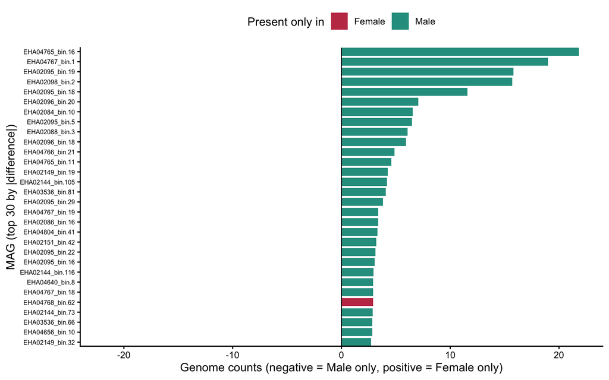

**Note:** Create a phylum-level summary bar chart showing the number of MAGs present only in each sex group, organized by phylum.

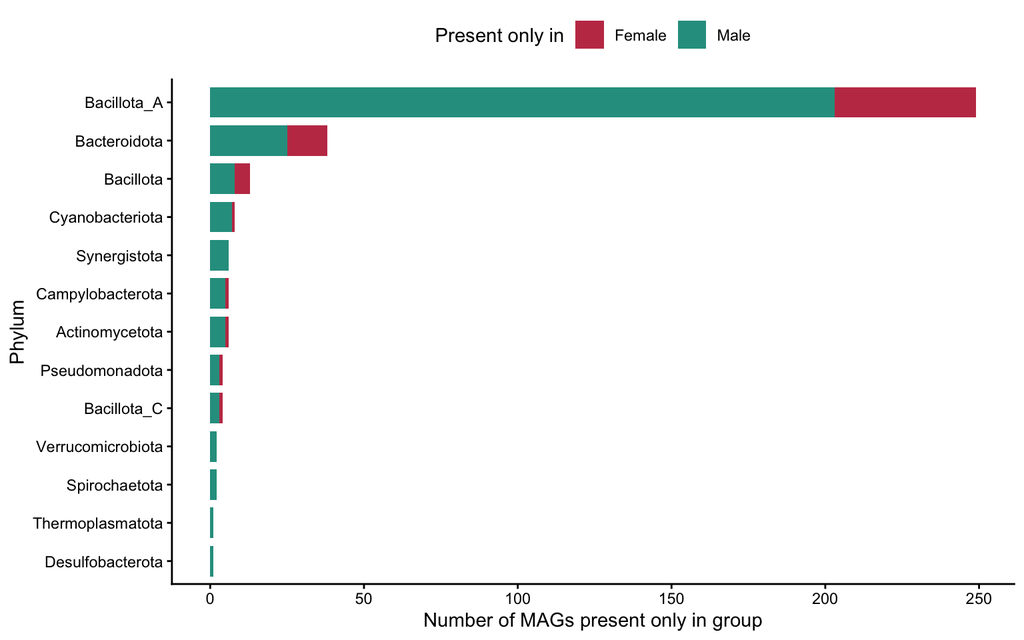

## 10.2 MAGs in different locations and shared among locations

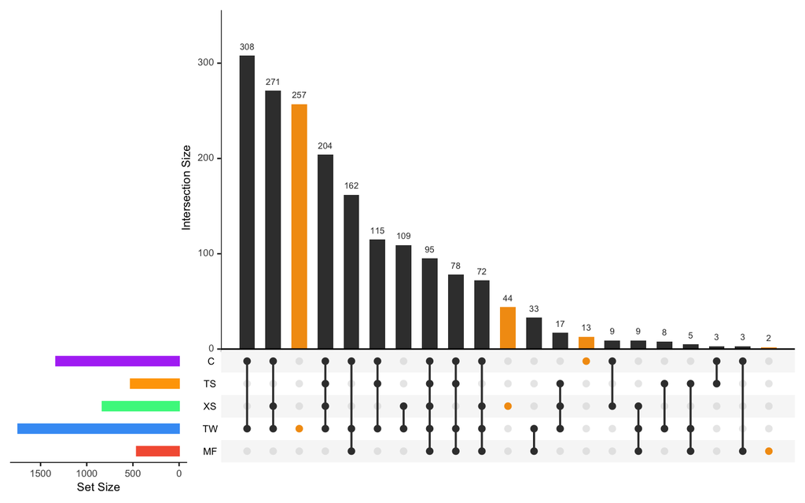

**Note:** Create a filtered phyloseq object excluding structural zeros for ANCOM-BC2 analysis. Replace zeros with a small pseudocount (0.00001) to enable log-transformation.

**Note:** Define helper functions to reduce code duplication for ANCOM-BC2 analyses, taxonomy processing, color schemes, and visualization.

### 10.2.1 With random effect

#### 10.2.1.1 MAG level

**Note:** Run ANCOM-BC2 analysis at MAG level with random effects for broad_environment to test differential abundance between sexes, accounting for environmental variation.

**Note:** Process ANCOM-BC2 results to extract significant MAGs (p < 0.05), merge with taxonomy information, and prepare color scheme for phylum-level visualization.

```
              taxon lfc_sexMale   p_sexMale      domain           phylum               class
1    EHA04661_bin.9   -4.973185 0.005970281 d__Bacteria     Bacteroidota      c__Bacteroidia
2  EHA04784_bin.104   -4.399128 0.007024158 d__Bacteria      Bacillota_A       c__Clostridia
3   EHA04659_bin.26   -4.195287 0.006458585 d__Bacteria      Bacillota_A       c__Clostridia
4   EHA04659_bin.24   -4.191656 0.007095842 d__Bacteria      Bacillota_A       c__Clostridia
5    EHA04651_bin.5   -4.101301 0.003261772 d__Bacteria      Bacillota_C    c__Negativicutes
6   EHA04812_bin.63   -4.045153 0.007042353 d__Bacteria     Synergistota      c__Synergistia
7   EHA04800_bin.38   -4.019865 0.009734689 d__Bacteria      Bacillota_A       c__Clostridia
8   EHA04658_bin.36   -3.668001 0.026341553 d__Bacteria      Bacillota_A       c__Clostridia
9   EHA02075_bin.37   -3.472339 0.026967123 d__Bacteria      Bacillota_A       c__Clostridia
10  EHA04665_bin.34   -3.310376 0.041648024 d__Bacteria      Bacillota_A       c__Clostridia
11  EHA04667_bin.27   -3.306840 0.028022371 d__Bacteria Desulfobacterota c__Desulfovibrionia
12  EHA04800_bin.51   -3.284176 0.033061243 d__Bacteria      Bacillota_A       c__Clostridia
13 EHA04772_bin.135   -3.267497 0.039036109 d__Bacteria      Bacillota_A       c__Clostridia
14  EHA02078_bin.11   -3.256323 0.016553509 d__Bacteria     Synergistota      c__Synergistia
```

[output cut: 69 more lines]

**Note:** Create a bar plot showing log2 fold changes for significantly differentially abundant MAGs between sexes, colored by phylum.

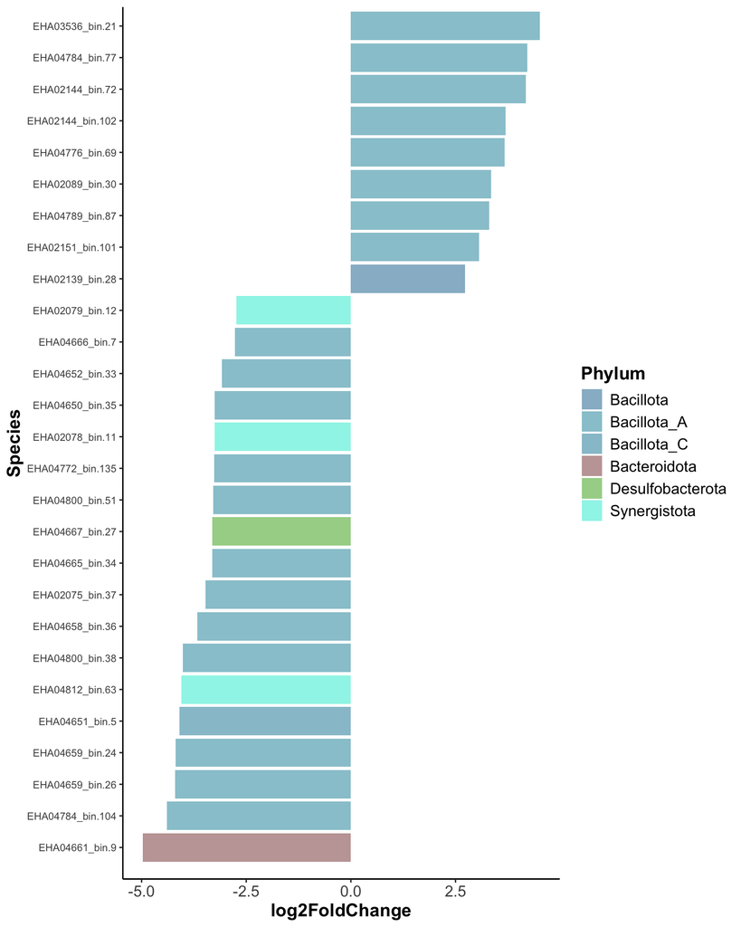

**Note:** Create a volcano plot showing log-fold change vs. p-value for all MAGs, with significant phyla highlighted in color.

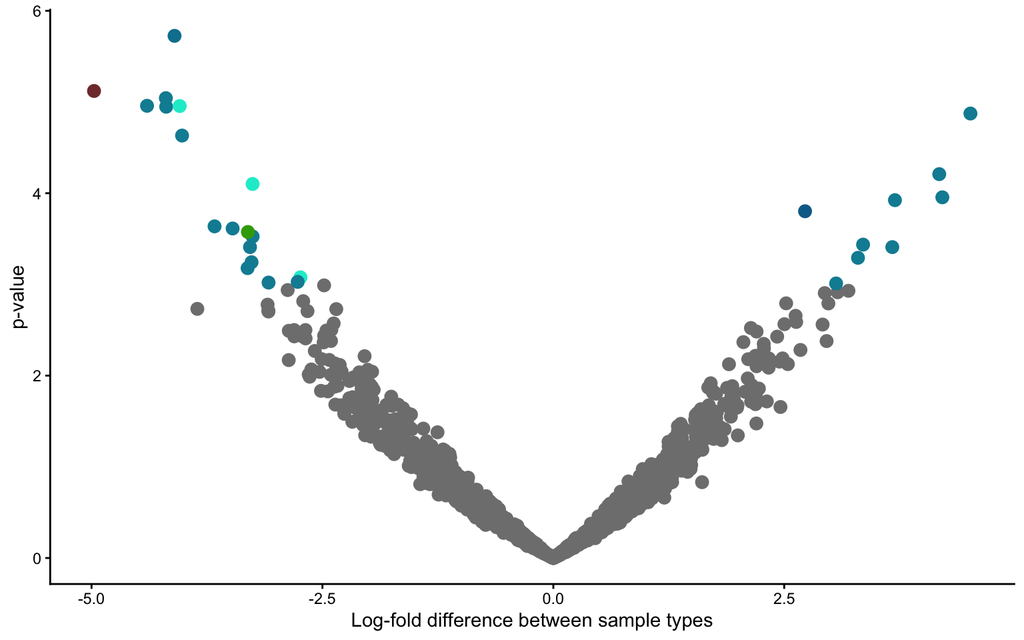

#### 10.2.1.2 Controlling structural components

**Note:** Run ANCOM-BC2 analysis at MAG level with random effects and structural zero detection enabled, grouping by sex to identify taxa that are completely absent in one group.

**Note:** Process ANCOM-BC2 results with structural zero control, extract significant MAGs, merge with taxonomy, and prepare phylum color scheme for visualization.

```
              taxon lfc_sexMale   p_sexMale      domain           phylum               class
1    EHA04661_bin.9   -4.973185 0.005970281 d__Bacteria     Bacteroidota      c__Bacteroidia
2  EHA04784_bin.104   -4.399128 0.007024158 d__Bacteria      Bacillota_A       c__Clostridia
3   EHA04659_bin.26   -4.195287 0.006458585 d__Bacteria      Bacillota_A       c__Clostridia
4   EHA04659_bin.24   -4.191656 0.007095842 d__Bacteria      Bacillota_A       c__Clostridia
5    EHA04651_bin.5   -4.101301 0.003261772 d__Bacteria      Bacillota_C    c__Negativicutes
6   EHA04812_bin.63   -4.045153 0.007042353 d__Bacteria     Synergistota      c__Synergistia
7   EHA04800_bin.38   -4.019865 0.009734689 d__Bacteria      Bacillota_A       c__Clostridia
8   EHA04658_bin.36   -3.668001 0.026341553 d__Bacteria      Bacillota_A       c__Clostridia
9   EHA02075_bin.37   -3.472339 0.026967123 d__Bacteria      Bacillota_A       c__Clostridia
10  EHA04665_bin.34   -3.310376 0.041648024 d__Bacteria      Bacillota_A       c__Clostridia
11  EHA04667_bin.27   -3.306840 0.028022371 d__Bacteria Desulfobacterota c__Desulfovibrionia
12  EHA04800_bin.51   -3.284176 0.033061243 d__Bacteria      Bacillota_A       c__Clostridia
13 EHA04772_bin.135   -3.267497 0.039036109 d__Bacteria      Bacillota_A       c__Clostridia
14  EHA02078_bin.11   -3.256323 0.016553509 d__Bacteria     Synergistota      c__Synergistia
```

[output cut: 69 more lines]

**Note:** Create a bar plot showing log2 fold changes for significantly differentially abundant MAGs (with structural zero control) between sexes, colored by phylum.

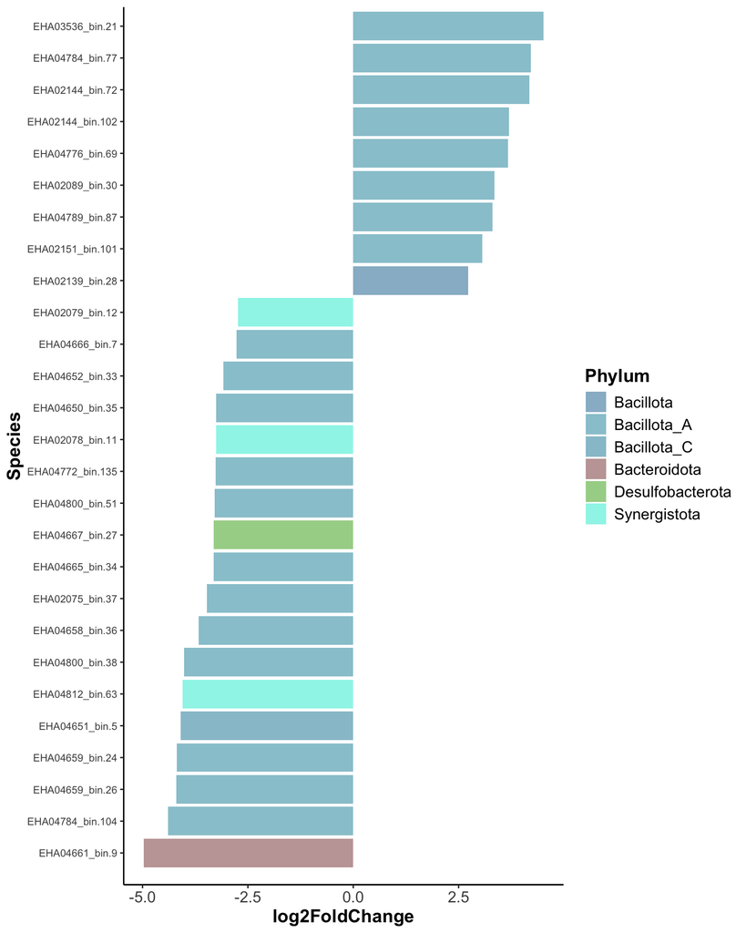

**Note:** Create a volcano plot for ANCOM-BC2 results with structural zero control, showing log-fold change vs. p-value with significant phyla highlighted.

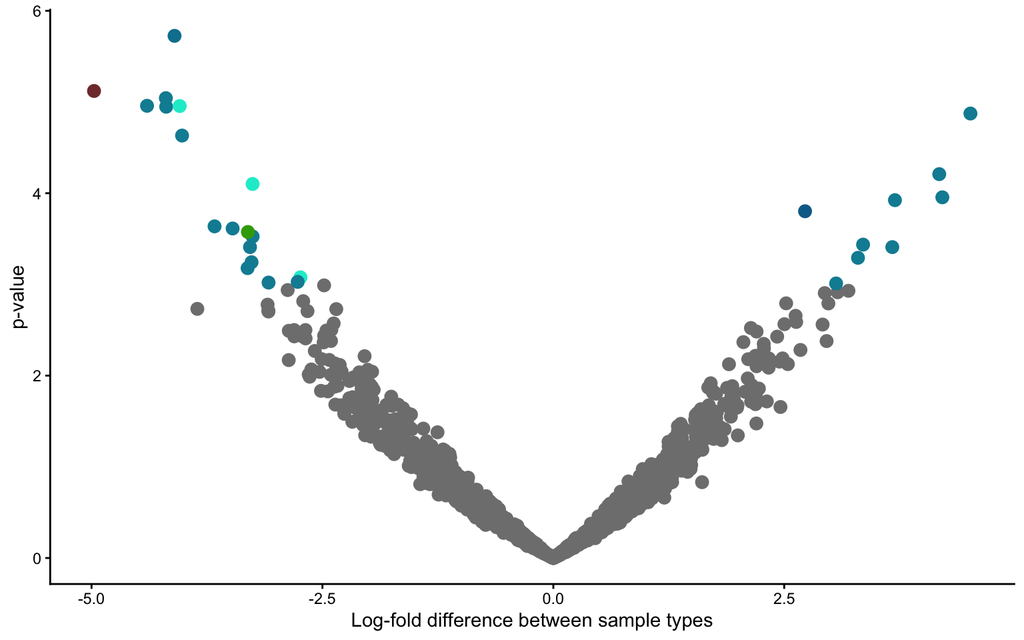

#### 10.2.1.3 Phylum level

**Note:** Run ANCOM-BC2 analysis aggregated at phylum level with random effects for broad_environment to test differential abundance between sexes.

**Note:** Extract and display significantly differentially abundant phyla (p < 0.05) from the ANCOM-BC2 results, sorted by p-value.

```
            taxon lfc_sexMale   p_sexMale
1  p__Bacillota_C   -4.101301 0.002240749
2 p__Synergistota   -3.373488 0.003515241
3 p__Bacteroidota   -3.491597 0.008893095
```

#### 10.2.1.4 Family level

**Note:** Run ANCOM-BC2 analysis aggregated at family level with random effects for broad_environment to test differential abundance between sexes.

**Note:** Extract and display significantly differentially abundant families (p < 0.05) from the ANCOM-BC2 results, sorted by p-value.

```
                       taxon lfc_sexMale   p_sexMale
1      f__Acidaminococcaceae   -4.101301 0.001836839
2 f__Dethiosulfovibrionaceae   -3.770701 0.002481652
3          f__Muribaculaceae   -3.835486 0.023877631
```

#### 10.2.1.5 Genera

**Note:** Run ANCOM-BC2 analysis aggregated at genus level with random effects for broad_environment to test differential abundance between sexes.

**Note:** Extract and display significantly differentially abundant genera (p < 0.05) from the ANCOM-BC2 results, sorted by p-value.

```
                       taxon lfc_sexMale   p_sexMale
1 g__Phascolarctobacterium_A   -4.101301 0.003371300
2          g__Pyramidobacter   -3.770701 0.004675902
3                g__JAJPXC01   -4.973185 0.006074830
4            g__Agathobacter   -2.591908 0.022444056
5           g__Desulfovibrio   -3.101803 0.032925044
6                  g__VSOB01   -3.391973 0.045617139
```

### 10.2.2 Without random effect

#### 10.2.2.1 MAG level

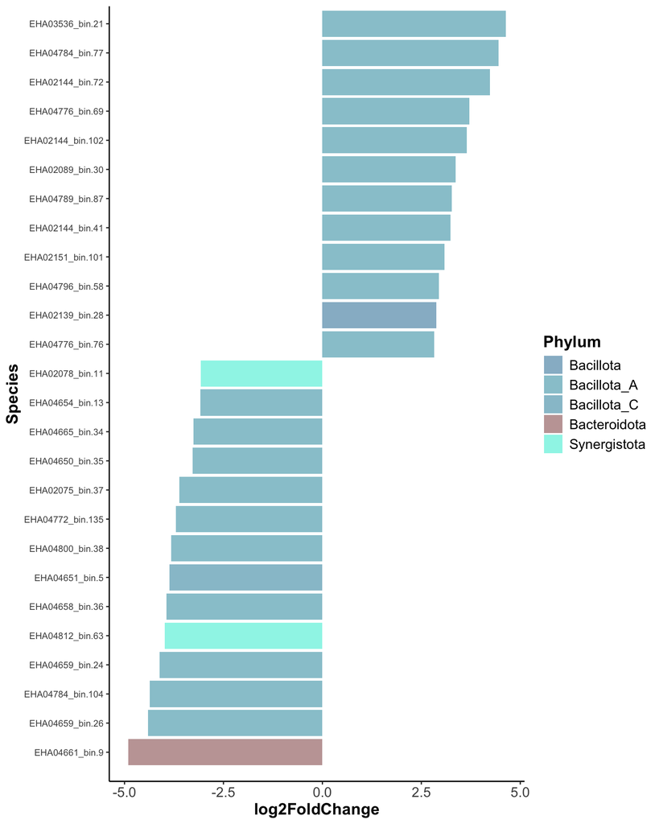

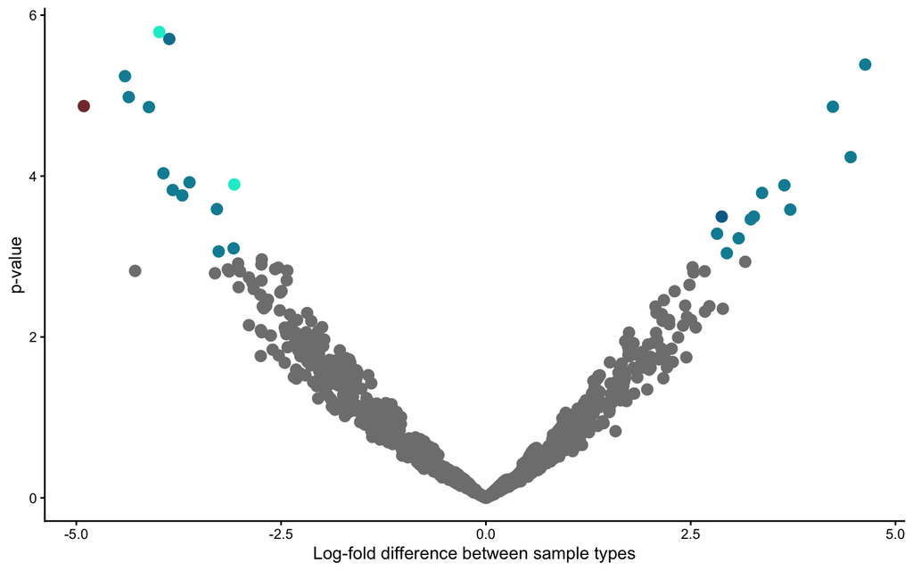

#### 10.2.2.2 Controlling structural components

**Note:** Run ANCOM-BC2 analysis at MAG level without random effects but with structural zero detection enabled, grouping by sex.

**Note:** Process ANCOM-BC2 results without random effects but with structural zero control, extract significant MAGs, merge with taxonomy, and prepare phylum color scheme.

**Note:** Create a bar plot showing log2 fold changes for significantly differentially abundant MAGs (without random effects, with structural zero control) between sexes, colored by phylum.

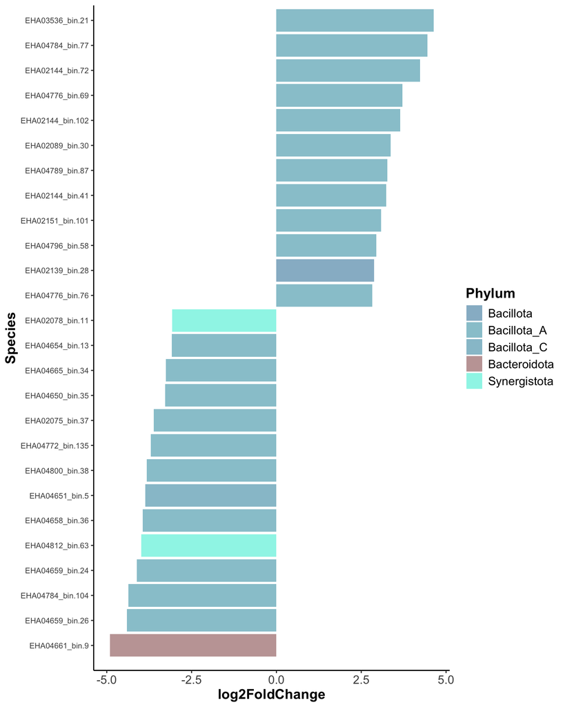

**Note:** Create a volcano plot for ANCOM-BC2 results without random effects but with structural zero control, showing log-fold change vs. p-value with significant phyla highlighted.

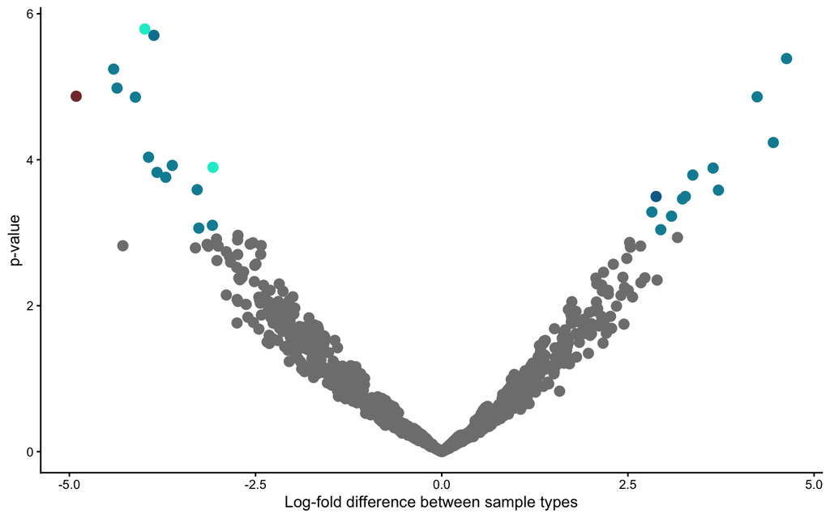

#### 10.2.2.3 Phylum level

**Note:** Run ANCOM-BC2 analysis aggregated at phylum level without random effects to test differential abundance between sexes.

**Note:** Extract and display significantly differentially abundant phyla (p < 0.05) from ANCOM-BC2 results without random effects, sorted by p-value.

```
            taxon lfc_sexMale   p_sexMale
1  p__Bacillota_C   -3.865516 0.001736464
2 p__Bacteroidota   -3.506357 0.003812189
3 p__Synergistota   -3.177806 0.004260671
```

#### 10.2.2.4 Family level

**Note:** Run ANCOM-BC2 analysis aggregated at family level without random effects to test differential abundance between sexes.

**Note:** Extract and display significantly differentially abundant families (p < 0.05) from ANCOM-BC2 results without random effects, sorted by p-value.

```
                       taxon lfc_sexMale   p_sexMale
1      f__Acidaminococcaceae   -3.865516 0.001892208
2 f__Dethiosulfovibrionaceae   -3.590885 0.002429797
3          f__Muribaculaceae   -4.197522 0.016492588
```

#### 10.2.2.5 Genera

**Note:** Run ANCOM-BC2 analysis aggregated at genus level without random effects to test differential abundance between sexes.

**Note:** Extract and display significantly differentially abundant genera (p < 0.05) from ANCOM-BC2 results without random effects, sorted by p-value.

```
                       taxon lfc_sexMale   p_sexMale
1 g__Phascolarctobacterium_A   -3.865516 0.003418467
2          g__Pyramidobacter   -3.590885 0.004503802
3                g__JAJPXC01   -4.908282 0.007757669
4            g__Agathobacter   -2.398290 0.025564487
5                  g__VSOB01   -3.417748 0.046087965
```

**Note:** Save all ANCOM-BC2 analysis results to an Rdata file for later use.